# Introduction to `derfinder`

## Filter coverage

Depending on the use case, you might want to filter the base level coverage at the time of reading it, or you might want to keep an unfiltered version. By default both `loadCoverage()` and `fullCoverage()` will not filter.

If you decide to filter, set the `cutoff` argument to a positive value. This will run `filterData()`. Note that you might want to standardize the library sizes prior to filtering, which can be done by supplying the `totalMapped` and `targetSize` arguments.

In this example, we prefer to keep both an unfiltered and filtered version. For the filtered version, we will retain the bases where at least one sample has coverage greater than 2.

```r
## Filter coverage
filteredCov <- lapply(fullCov, filterData, cutoff = 2)
```

```r
## 2014-09-30 18:43:46 filterData: originally there were 48129895 rows, now there are 130356 rows. Meaning that 99.73 percent was filtered.
```

The result is similar to `fullCov` but with the genomic position index as shown below.

```r
## Similar to fullCov but with $position
filteredCov
```

```r
## $chr21
## $chr21$coverage
## DataFrame with 130356 rows and 12 columns
##        HSB113 HSB123 HSB126 HSB130 HSB135 HSB136 HSB145 HSB153 HSB159
##
## 1        2.01      0   0.00   0.04   0.23   0.13      0   0.59   0.15
## 2        2.17      0   0.00   0.04   0.23   0.13      0   0.63   0.15
## 3        2.21      0   0.00   0.04   0.23   0.13      0   0.67   0.15
## 4        2.37      0   0.00   0.04   0.23   0.13      0   0.71   0.15
## 5        2.37      0   0.06   0.04   0.23   0.13      0   0.75   0.25
## ...       ...    ...    ...    ...    ...    ...    ...    ...    ...
## 130352   1.25   1.28   2.05   0.79   1.63   1.37   1.03   2.21   2.46
## 130353   1.21   1.24   2.05   0.79   1.63   1.37   1.03   2.21   2.46
## 130354   1.21   1.20   1.93   0.79   1.63   1.28   0.73   2.01   2.21
## 130355   1.17   1.20   1.93   0.79   1.63   1.28   0.60   2.01   2.11
## 130356   1.17   1.09   1.87   0.79   1.55   1.02   0.56   1.93   1.96
##        HSB178 HSB92 HSB97
##
## 1        0.05  0.07  1.58
## 2        0.05  0.07  1.58
## 3        0.05  0.10  1.61
## 4        0.05  0.13  1.65
## 5        0.10  0.13  1.68
## ...       ...   ...   ...
## 130352   2.07  2.23  1.51
## 130353   2.07  2.23  1.51
## 130354   2.11  2.13  1.47
## 130355   2.11  2.13  1.47
## 130356   1.78  2.06  1.47
##
## $chr21$position
## logical-Rle of length 48129895 with 3235 runs
##   Lengths: 9825448     149       2       9 ...     740     598   45091
##   Values :   FALSE    TRUE   FALSE    TRUE ...   FALSE    TRUE   FALSE
```

In terms of memory, the filtered version requires less resources. Although this will depend on how rich the data set is and how aggressive was the filtering step.

```r
## Compare the size in Mb
round(c(fullCov = object.size(fullCov), filteredCov = object.size(filteredCov)) / 1024^2, 1)
```

```r
##     fullCov filteredCov
##        22.7         8.5
```

## DER analysis

One form of base-level differential expression analysis implemented in `derfinder` is to calculate F-statistics for every base and use them to define candidate differentially expressed regions. This type of analysis is further explained in this section.

### Models

Once we have the base-level coverage data for all 12 samples, we can construct the models. In this case, we want to find differences between fetal and adult samples while adjusting for gender and a proxy of the library size.

We can use `sampleDepth()` and it's helper function `collapseFullCoverage()` to get a proxy of the library size. Note that you would normally use the unfiltered data from all the chromosomes in this step and not just one.

```r
## Get some idea of the library sizes
sampleDepths <- sampleDepth(collapseFullCoverage(fullCov), 1)
```

```r
## 2014-09-30 18:43:46 sampleDepth: Calculating sample quantiles
## 2014-09-30 18:43:52 sampleDepth: Calculating sample adjustments
```

```r
sampleDepths
```

```r
## HSB113.100% HSB123.100% HSB126.100% HSB130.100% HSB135.100% HSB136.100%
##       19.82       19.41       19.53       19.52       20.33       19.98
## HSB145.100% HSB153.100% HSB159.100% HSB178.100%  HSB92.100%  HSB97.100%
##       19.50       19.41       19.24       19.44       19.56       19.48
```

`sampleDepth()` is similar to `calcNormFactors()` from [metagenomeSeq](http://www.bioconductor.org/packages/release/bioc/html/metagenomeSeq.html) with some code underneath tailored for the type of data we are using. `collapseFullCoverage()` is only needed to deal with the size of the data.

We can then define the nested models we want to use using `makeModels()`. This is a helper function that assumes that you will always adjust for the library size. You then need to define the variable to test, in this case we are comparing fetal vs adult samples. Optionally, you can adjust for other sample covariates, such as the gender in this case.

```r
## Define models
models <- makeModels(sampleDepths, testvars = pheno$group, adjustvars = pheno[, c('gender')])

## Explore the models
lapply(models, head)
```

```r
## $mod
##   (Intercept) testvarsadult sampleDepths adjustVar1M
## 1           1             0        19.82           0
## 2           1             0        19.41           1
## 3           1             0        19.53           1
## 4           1             0        19.52           1
## 5           1             0        20.33           0
## 6           1             0        19.98           0
##
## $mod0
##   (Intercept) sampleDepths adjustVar1M
## 1           1        19.82           0
## 2           1        19.41           1
## 3           1        19.53           1
## 4           1        19.52           1
## 5           1        20.33           0
## 6           1        19.98           0
```

Note how the null model (`mod0`) is nested in the alternative model (`mod`). `derfinder` is very flexible and works with any type of nested model.

### Find candidate DERs

Next, we can find candidate differentially expressed regions (DERs) using as input the segments of the genome where at least one sample has coverage greater than 2. That is, the filtered coverage version we created previously.

The **main** function in `derfinder` for this type of analysis is `analyzeChr()`. It works at a chromosome level and runs behinds the scenes several other `derfinder` functions. To use it, you have to provide the models, the grouping information, how to calculate the F-statistic cutoff and most importantly, the number of permutations.

By default `analyzeChr()` will use a theoretical cutoff. In this example, we use the cutoff that would correspond to a p-value of 0.05. To assign p-values to the candidate DERs, `derfinder` permutes the rows of the model matrices, re-calculates the F-statistics and identifies null regions. Then it compares the area of the observed regions versus the areas from the null regions to assign an empirical p-value.

In this example we will use twenty permutations, although in a real case scenario you might consider using up to a thousand.

In real scenario, you might consider saving the results from all the chromosomes in a given directory. Here we will use *analysisResults*. For each chromosome you analyze, a new directory with the chromosome-specific data will be created. So in this case, we will have *analysisResults/chr21*.

```r
## Create a analysis directory
dir.create('analysisResults')
originalWd <- getwd()
setwd(file.path(originalWd, 'analysisResults'))

## Perform differential expression analysis
system.time(results <- analyzeChr(chr = 'chr21', filteredCov$chr21, models, groupInfo = pheno$group, writeOutput = TRUE, cutoffFstat = 5e-02, nPermute = 20, seeds = 20140923 + seq_len(20), returnOutput = TRUE))
```

```r
## 2014-09-30 18:43:53 analyzeChr: Pre-processing the coverage data
## 2014-09-30 18:43:59 analyzeChr: Calculating statistics
## 2014-09-30 18:43:59 calculateStats: calculating the F-statistics
## 2014-09-30 18:43:59 analyzeChr: Calculating pvalues
## 2014-09-30 18:43:59 analyzeChr: Using the following theoretical cutoff for the F-statistics 5.31765507157871
## 2014-09-30 18:43:59 calculatePvalues: identifying data segments
## 2014-09-30 18:43:59 findRegions: segmenting F-stats information
## 2014-09-30 18:43:59 findRegions: identifying candidate DERs
## 2014-09-30 18:43:59 findRegions: identifying DER clusters
## 2014-09-30 18:44:00 calculatePvalues: calculating F-statistics for permutation 1 and seed 20140924
## 2014-09-30 18:44:00 findRegions: segmenting F-stats information
## 2014-09-30 18:44:00 findRegions: identifying candidate DERs
## 2014-09-30 18:44:01 calculatePvalues: calculating F-statistics for permutation 2 and seed 20140925
## 2014-09-30 18:44:01 findRegions: segmenting F-stats information
## 2014-09-30 18:44:01 findRegions: identifying candidate DERs
## 2014-09-30 18:44:01 calculatePvalues: calculating F-statistics for permutation 3 and seed 20140926
## 2014-09-30 18:44:01 findRegions: segmenting F-stats information
## 2014-09-30 18:44:01 findRegions: identifying candidate DERs
## 2014-09-30 18:44:01 calculatePvalues: calculating F-statistics for permutation 4 and seed 20140927
## 2014-09-30 18:44:02 findRegions: segmenting F-stats information
## 2014-09-30 18:44:02 findRegions: identifying candidate DERs
## 2014-09-30 18:44:02 calculatePvalues: calculating F-statistics for permutation 5 and seed 20140928
## 2014-09-30 18:44:02 findRegions: segmenting F-stats information
## 2014-09-30 18:44:02 findRegions: identifying candidate DERs
## 2014-09-30 18:44:02 calculatePvalues: calculating F-statistics for permutation 6 and seed 20140929
## 2014-09-30 18:44:02 findRegions: segmenting F-stats information
## 2014-09-30 18:44:02 findRegions: identifying candidate DERs
## 2014-09-30 18:44:02 calculatePvalues: calculating F-statistics for permutation 7 and seed 20140930
## 2014-09-30 18:44:03 findRegions: segmenting F-stats information
## 2014-09-30 18:44:03 findRegions: identifying candidate DERs
## 2014-09-30 18:44:03 calculatePvalues: calculating F-statistics for permutation 8 and seed 20140931
## 2014-09-30 18:44:03 findRegions: segmenting F-stats information
## 2014-09-30 18:44:03 findRegions: identifying candidate DERs
## 2014-09-30 18:44:03 calculatePvalues: calculating F-statistics for permutation 9 and seed 20140932
## 2014-09-30 18:44:04 findRegions: segmenting F-stats information
## 2014-09-30 18:44:04 findRegions: identifying candidate DERs
## 2014-09-30 18:44:04 calculatePvalues: calculating F-statistics for permutation 10 and seed 20140933
## 2014-09-30 18:44:04 findRegions: segmenting F-stats information
## 2014-09-30 18:44:04 findRegions: identifying candidate DERs
## 2014-09-30 18:44:04 calculatePvalues: calculating F-statistics for permutation 11 and seed 20140934
## 2014-09-30 18:44:04 findRegions: segmenting F-stats information
## 2014-09-30 18:44:04 findRegions: identifying candidate DERs
## 2014-09-30 18:44:04 calculatePvalues: calculating F-statistics for permutation 12 and seed 20140935
## 2014-09-30 18:44:05 findRegions: segmenting F-stats information
## 2014-09-30 18:44:05 findRegions: identifying candidate DERs
## 2014-09-30 18:44:05 calculatePvalues: calculating F-statistics for permutation 13 and seed 20140936
## 2014-09-30 18:44:05 findRegions: segmenting F-stats information
## 2014-09-30 18:44:05 findRegions: identifying candidate DERs
## 2014-09-30 18:44:05 calculatePvalues: calculating F-statistics for permutation 14 and seed 20140937
## 2014-09-30 18:44:05 findRegions: segmenting F-stats information
## 2014-09-30 18:44:05 findRegions: identifying candidate DERs
## 2014-09-30 18:44:05 calculatePvalues: calculating F-statistics for permutation 15 and seed 20140938
## 2014-09-30 18:44:06 findRegions: segmenting F-stats information
## 2014-09-30 18:44:06 findRegions: identifying candidate DERs
## 2014-09-30 18:44:06 calculatePvalues: calculating F-statistics for permutation 16 and seed 20140939
## 2014-09-30 18:44:06 findRegions: segmenting F-stats information
## 2014-09-30 18:44:06 findRegions: identifying candidate DERs
## 2014-09-30 18:44:06 calculatePvalues: calculating F-statistics for permutation 17 and seed 20140940
## 2014-09-30 18:44:06 findRegions: segmenting F-stats information
## 2014-09-30 18:44:06 findRegions: identifying candidate DERs
## 2014-09-30 18:44:06 calculatePvalues: calculating F-statistics for permutation 18 and seed 20140941
## 2014-09-30 18:44:07 findRegions: segmenting F-stats information
## 2014-09-30 18:44:07 findRegions: identifying candidate DERs
## 2014-09-30 18:44:07 calculatePvalues: calculating F-statistics for permutation 19 and seed 20140942
## 2014-09-30 18:44:07 findRegions: segmenting F-stats information
## 2014-09-30 18:44:07 findRegions: identifying candidate DERs
## 2014-09-30 18:44:07 calculatePvalues: calculating F-statistics for permutation 20 and seed 20140943
## 2014-09-30 18:44:08 findRegions: segmenting F-stats information
## 2014-09-30 18:44:08 findRegions: identifying candidate DERs
## 2014-09-30 18:44:08 calculatePvalues: calculating the p-values
## 2014-09-30 18:44:09 analyzeChr: Annotating regions
```

```r
## Matching regions to genes.
## nearestgene: loading bumphunter hg19 transcript database
## finding nearest transcripts...
## AnnotatingDone.
```

```r
##    user  system elapsed
##  39.500   1.555  40.918
```

To speed up `analyzeChr()`, you might need to use several cores via the `mc.cores` argument. If memory is limiting, you might want to use a smaller `chunksize` (default is 5 million). Note that if you use too many cores, you might hit the input/output ceiling of your data network and/or hard drives speed.

Before using a large number of permutations we recommend exploring how long each permutation cycle takes using a single permutation.

### Explore results

When using `returnOutput = TRUE`, `analyzeChr()` will return a list with the results to explore interactively. However, by default it writes the results to disk (one .Rdata file per result).

The following code explores the results.

```r
## Explore
names(results)
```

```r
## [1] "timeinfo"     "optionsStats" "coveragePrep" "fstats"
## [5] "regions"      "annotation"
```

#### optionStats

`optionStats` stores the main options used in the `analyzeChr()` call including the models used, the type of cutoff, number of permutations, seeds for the permutations. All this information can be useful to reproduce the analysis.

```r
## Explore optionsStats
names(results$optionsStats)
```

```r
##  [1] "models"          "cutoffPre"       "scalefac"
##  [4] "chunksize"       "cutoffFstat"     "cutoffType"
##  [7] "nPermute"        "seeds"           "groupInfo"
## [10] "lowMemDir"       "analyzeCall"     "cutoffFstatUsed"
## [13] "returnOutput"
```

```r
## Call used
results$optionsStats$analyzeCall
```

```r
## analyzeChr(chr = "chr21", coverageInfo = filteredCov$chr21, models = models,
##     cutoffFstat = 0.05, nPermute = 20, seeds = 20140923 + seq_len(20),
##     groupInfo = pheno$group, writeOutput = TRUE, returnOutput = TRUE)
```

#### coveragePrep

`coveragePrep` has the result from the `preprocessCoverage()` step. This includes the genomic position index, the mean coverage (after scaling and the log2 transformation) for all the samples, and the group mean coverages. By default, the chunks are written to disk in `optionsStats$lowMemDir` (chr21/chunksDir in this example) to help reduce the required memory resources. Otherwise it is stored in `coveragePrep$coverageProcessed`.

```r
## Explore coveragePrep
names(results$coveragePrep)
```

```r
## [1] "coverageProcessed" "mclapplyIndex"     "position"
## [4] "meanCoverage"      "groupMeans"
```

```r
## Group means
results$coveragePrep$groupMeans
```

```r
## $fetal
## numeric-Rle of length 130356 with 116452 runs
##   Lengths:                 1                 1 ...                 1
##   Values : 0.401666664828857 0.428333345800638 ...  1.24833332498868
##
## $adult
## numeric-Rle of length 130356 with 119226 runs
##   Lengths:                 1                 1 ...                 1
##   Values : 0.406666670615474  0.41333334085842 ...   1.6266666551431
```

#### fstats

The F-statistics are then stored in `fstats`. These are calculated using `calculateStats()`.

```r
## Explore optionsStats
results$fstats
```

```r
## numeric-Rle of length 130356 with 126807 runs
##   Lengths:                   1                   1 ...                   1
##   Values :  0.0192260952849003  0.0299693665742238 ...    2.32463844414503
```

```r
## Note that the length matches the number of bases used
identical(length(results$fstats), sum(results$coveragePrep$position))
```

```r
## [1] TRUE
```

#### regions

The candidate DERs and summary results from the permutations is then stored in `regions`. This is the output from `calculatePvalues()` which uses several underneath other functions including `calculateStats()` and `findRegions()`.

```r
## Explore regions
names(results$regions)
```

```r
## [1] "regions"         "nullStats"       "nullWidths"      "nullPermutation"
```

For the null regions, the summary information is composed of the mean F-statistic for the null regions (`regions$nullStats`), the width of the null regions (`regions$nullWidths`), and the permutation number under which they were identified (`regions$nullPermutation`).

```r
## Permutation summary information
results$regions[2:4]
```

```r
## $nullStats
## numeric-Rle of length 15032 with 15030 runs
##   Lengths:                1                1 ...                1
##   Values : 12.2254943226418 5.42502250701367 ... 9.56804518038913
##
## $nullWidths
## integer-Rle of length 15032 with 13299 runs
##   Lengths:   1   1   1   1   1   1   1   1 ...   1   1   1   1   1   1   1
##   Values :   8   2  50   2   1   2   1   3 ...   7   3  25   2  20   1 151
##
## $nullPermutation
## integer-Rle of length 15032 with 20 runs
##   Lengths: 1048 2732  780 1356  386 1238 ...  858  280  250  178  312  954
##   Values :    1    2    3    4    5    6 ...   15   16   17   18   19   20
```

The most important part of the output is the `GRanges` object with the candidate DERs shown below.

```r
## Candidate DERs
results$regions$regions
```

```r
## GRanges object with 549 ranges and 14 metadata columns:
##       seqnames               ranges strand   |     value      area
##                           |
##    up    chr21 [47610386, 47610682]      *   |    11.103      3298
##    up    chr21 [40196145, 40196444]      *   |    10.061      3018
##    up    chr21 [27253616, 27253948]      *   |     8.435      2809
##    up    chr21 [22115534, 22115894]      *   |     7.236      2612
##    up    chr21 [22914853, 22915064]      *   |     9.781      2073
##   ...      ...                  ...    ... ...       ...       ...
##    up    chr21 [35889784, 35889784]      *   |     5.320     5.320
##    up    chr21 [47610093, 47610093]      *   |     5.319     5.319
##    up    chr21 [16333728, 16333728]      *   |     5.319     5.319
##    up    chr21 [34001896, 34001896]      *   |     5.319     5.319
##    up    chr21 [34809571, 34809571]      *   |     5.318     5.318
##       indexStart  indexEnd cluster clusterL meanCoverage meanfetal
##
##    up     122158    122454     139      933       1.5980    0.8229
##    up      76110     76409      71     1323       1.3035    2.0253
##    up      22019     22351      28      407      33.6579   42.4670
##    up      12274     12634       9      694       0.9645    1.7191
##    up      17318     17529      21      217       2.8390    4.2359
##   ...        ...       ...     ...      ...          ...       ...
##    up      60088     60088      51      742        2.754     3.360
##    up     121865    121865     139      933        1.456     0.775
##    up       5048      5048       1        9        1.195     1.232
##    up      32577     32577      38     1428        1.713     2.333
##    up      43694     43694      46      149        2.950     2.878
##       meanadult log2FoldChangeadultvsfetal   pvalues significant   qvalues
##
##    up    2.3730                     1.5279   0.01111        TRUE    0.9577
##    up    0.5817                    -1.7998   0.01271        TRUE    0.9577
##    up   24.8487                    -0.7732   0.01350        TRUE    0.9577
##    up    0.2099                    -3.0340   0.01430        TRUE    0.9577
##    up    1.4420                    -1.5546   0.02055        TRUE    0.9577
##   ...       ...                        ...       ...         ...       ...
##    up     2.148                   -0.64524    0.9977       FALSE    0.9996
##    up     2.137                    1.46309    0.9981       FALSE    0.9996
##    up     1.158                   -0.08856    0.9987       FALSE    0.9996
##    up     1.092                   -1.09586    0.9991       FALSE    0.9996
##    up     3.022                    0.07011    0.9996       FALSE    0.9996
##       significantQval
##
##    up           FALSE
##    up           FALSE
##    up           FALSE
##    up           FALSE
##    up           FALSE
##   ...             ...
##    up           FALSE
##    up           FALSE
##    up           FALSE
##    up           FALSE
##    up           FALSE
##   -------
##   seqinfo: 1 sequence from an unspecified genome; no seqlengths
```

The metadata columns are:

- *value* is the mean F-statistics for the candidate DER.
- *area* is the sum of the F-statistics for the candidate DER.
- *indexStart* Relates the genomic start coordinate with the filtered genomic index start coordinate.
- *indexEnd* Similarly as above but for the end coordinates.
- *cluster* The cluster id to which this candidate DER belongs to.
- *clusterL* The length of the cluster to which this candidate DER belongs to.
- *meanCoverage* The base level mean coverage for the candidate DER.
- *meanfetal* In this example, the mean coverage for the fetal samples.
- *meanadult* In this example, the mean coverage for the adult samples.
- *log2FoldChangeadultvsfetal* In this example, the log2 fold change between adult vs fetal samples.
- *pvalues* The p-value for the candidate DER.
- *significant* By default, whether the p-value is less than 0.05 or not.
- *qvalues* The q-value for the candidate DER calculated with [qvalue](http://www.bioconductor.org/packages/release/bioc/html/qvalue.html).
- *significantQval* By default, whether the q-value is less than 0.10 or not.

Note that for this type of analysis you might want to try a few coverage cutoffs and/or F-statistic cutoffs. One quick way to evaluate the results is to compare the width of the regions.

```r
## Width of potential DERs
summary(width(results$regions$regions))
```

```r
##    Min. 1st Qu.  Median    Mean 3rd Qu.    Max.
##     1.0     1.0     4.0    19.4    18.0   361.0
```

```r
sum(width(results$regions$regions) > 50)
```

```r
## [1] 68
```

```r
## Width of candidate DERs
sig <- as.logical(results$regions$regions$significant)
summary(width(results$regions$regions[ sig ]))
```

```r
##    Min. 1st Qu.  Median    Mean 3rd Qu.    Max.
##      76     101     153     174     204     361
```

```r
sum(width(results$regions$regions[ sig ]) > 50)
```

```r
## [1] 18
```

#### Nearest annotation

`analyzeChr()` will find the nearest annotation feature using `annotateNearest()` from [bumphunter](http://www.bioconductor.org/packages/release/bioc/html/bumphunter.html). This information is useful considering that the candidate DERs were identified without relying on annotation. Yet at the end, we are interested to check if they are inside a known exon, upstream a gene, etc.

```r
## Nearest annotation
head(results$annotation)
```

```r
##        name
## 1       LSS
## 2      ETS2
## 3       APP
## 4 LINC00320
## 5     NCAM2
## 6       CBS
##                                                                                                                                                                                                                                          annotation
## 1                                                                                             NM_001001438 NM_001145436 NM_001145437 NM_002340 NP_001001438 NP_001138908 NP_001138909 NP_002331 XM_006724003 XM_006724004 XP_006724066 XP_006724067
## 2                                                                                                                                                                           NM_001256295 NM_005239 NP_001243224 NP_005230 XM_005260935 XP_005260992
## 3 NM_000484 NM_001136016 NM_001136129 NM_001136130 NM_001136131 NM_001204301 NM_001204302 NM_001204303 NM_201413 NM_201414 NP_000475 NP_001129488 NP_001129601 NP_001129602 NP_001129603 NP_001191230 NP_001191231 NP_001191232 NP_958816 NP_958817
## 4                                                                                                                                                                                                           NR_024090 NR_109786 NR_109787 NR_109788
## 5                                                                                                                       NM_004540 NP_004531 XM_005260988 XM_006724007 XM_006724008 XM_006724009 XP_005261045 XP_006724070 XP_006724071 XP_006724072
## 6                                                                                                                                                 NM_000071 NM_001178008 NM_001178009 NP_000062 NP_001171479 NP_001171480 XM_006724057 XP_006724120
##          description     region distance          subregion insidedistance
## 1        inside exon     inside    38056        inside exon              0
## 2        inside exon     inside    18390        inside exon              0
## 3        inside exon     inside   289498        inside exon              0
## 4                              0                            NA
## 5         downstream downstream   544220                            NA
## 6 overlaps two exons     inside    10975 overlaps two exons              0
##   exonnumber nexons                         UTR strand  geneL codingL
## 1         22     22                       3'UTR      -  39700   37641
## 2         10     10                       3'UTR      +  19123   12854
## 3         16     16                       3'UTR      - 290585  230434
## 4         NA      7                              -      0       0
## 5         NA     18                              + 541884  539396
## 6          8     18 inside transcription region      -  23171   18313
```

For more details on the output please check the [bumphunter](http://www.bioconductor.org/packages/release/bioc/html/bumphunter.html) package.

#### Time spent

The final piece is the wallclock time spent during each of the steps in `analyzeChr()`.

```r
## Time spent
results$timeinfo
```

```r
##                      init                     setup
## "2014-09-30 18:43:53 EDT" "2014-09-30 18:43:53 EDT"
##                  prepData                  savePrep
## "2014-09-30 18:43:58 EDT" "2014-09-30 18:43:59 EDT"
##            calculateStats                 saveStats
## "2014-09-30 18:43:59 EDT" "2014-09-30 18:43:59 EDT"
##             saveStatsOpts          calculatePvalues
## "2014-09-30 18:43:59 EDT" "2014-09-30 18:44:09 EDT"
##                  saveRegs                  annotate
## "2014-09-30 18:44:09 EDT" "2014-09-30 18:44:33 EDT"
##                  saveAnno
## "2014-09-30 18:44:33 EDT"
```

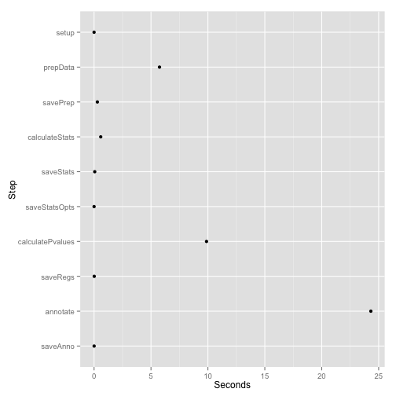

```r
## Use this information to make a plot
timed <- diff(results$timeinfo)
timed.df <- data.frame(Seconds = as.numeric(timed), Step = factor(names(timed),
    levels = rev(names(timed))))
library('ggplot2')
ggplot(timed.df, aes(y = Step, x = Seconds)) + geom_point()
```

### Merge results

Once you have analyzed each chromosome using `analyzeChr()`, you can use `mergeResults()` to merge the results. This function does not return an object in R but instead creates several Rdata files with the main results from the different chromosomes.

```r
## Go back to the original directory
setwd(originalWd)

## Merge results from several chromosomes. In this case we only have one.
mergeResults(chrs='chr21', prefix="analysisResults",
    genomicState = genomicState$fullGenome,
    optionsStats = results$optionsStats)
```

```r
## 2014-09-30 18:44:34 mergeResults: Saving options used
## 2014-09-30 18:44:34 Loading chromosome chr21
## 2014-09-30 18:44:35 mergeResults: calculating FWER
## 2014-09-30 18:44:35 mergeResults: Saving fullNullSummary
## 2014-09-30 18:44:35 mergeResults: Re-calculating the p-values
## 2014-09-30 18:44:35 mergeResults: Saving fullRegions
## 2014-09-30 18:44:35 mergeResults: assigning genomic states
## 2014-09-30 18:44:35 annotateRegions: counting
## 2014-09-30 18:44:35 annotateRegions: annotating
## 2014-09-30 18:44:35 mergeResults: Saving fullAnnotatedRegions
## 2014-09-30 18:44:35 mergeResults: Saving fullFstats
## 2014-09-30 18:44:35 mergeResults: Saving fullTime
```

```r
## Files created by mergeResults()
dir('analysisResults', pattern = '.Rdata')
```

```r
## [1] "fullAnnotatedRegions.Rdata" "fullFstats.Rdata"
## [3] "fullNullSummary.Rdata"      "fullRegions.Rdata"
## [5] "fullTime.Rdata"             "optionsMerge.Rdata"
```

- *fullFstats.Rdata* contains a list with one element per chromosome. Per chromosome it has the F-statistics.
- *fullNullSummary.Rdata* is a list with the summary information from the null regions stored for each chromosome.
- *fullTime.Rdata* has the timing information for each chromosome as a list.

#### optionsMerge

For reproducibility purposes, the options used the merge the results are stored in `optionsMerge`.

```r
## Options used to merge
load(file.path('analysisResults', 'optionsMerge.Rdata'))

## Contents
names(optionsMerge)
```

```r
## [1] "chrs"            "significantCut"  "minoverlap"      "mergeCall"
## [5] "cutoffFstatUsed" "optionsStats"
```

```r
## Merge call
optionsMerge$mergeCall
```

```r
## mergeResults(chrs = "chr21", prefix = "analysisResults", genomicState = genomicState$fullGenome,
##     optionsStats = results$optionsStats)
```

#### fullRegions

The main result from `mergeResults()` is in `fullRegions`. This is a `GRanges` object with the candidate DERs from all the chromosomes. It also includes the nearest annotation metadata as well as FWER adjusted p-values (*fwer*) and whether the FWER adjusted p-value is less than 0.05 (*significantFWER*).

```r
## Load all the regions
load(file.path('analysisResults', 'fullRegions.Rdata'))

## Metadata columns
names(mcols(fullRegions))
```

```r
##  [1] "value"                      "area"
##  [3] "indexStart"                 "indexEnd"
##  [5] "cluster"                    "clusterL"
##  [7] "meanCoverage"               "meanfetal"
##  [9] "meanadult"                  "log2FoldChangeadultvsfetal"
## [11] "pvalues"                    "significant"
## [13] "qvalues"                    "significantQval"
## [15] "name"                       "annotation"
## [17] "description"                "region"
## [19] "distance"                   "subregion"
## [21] "insidedistance"             "exonnumber"
## [23] "nexons"                     "UTR"
## [25] "annoStrand"                 "geneL"
## [27] "codingL"                    "fwer"
## [29] "significantFWER"
```

Note that `analyzeChr()` only has the information for a given chromosome at a time, so `mergeResults()` re-calculates the p-values and q-values using the information from all the chromosomes.

#### fullAnnotatedRegions

In preparation for visually exploring the results, `mergeResults()` will run `annotateRegions()` which counts how many known exons, introns and intragenic segments each candidate DER overlaps (by default with a minimum overlap of 20bp). `annotateRegions()` uses a summarized version of the genome annotation created with `makeGenomicState()`. For this example, we can use the data included in `derfinder` which is the summarized annotation of hg19 for chromosome 21.

```r
## Load annotateRegions() output
load(file.path('analysisResults', 'fullAnnotatedRegions.Rdata'))

## Information stored
names(fullAnnotatedRegions)
```

```r
## [1] "countTable"     "annotationList"
```

```r
## Take a peak
lapply(fullAnnotatedRegions, head)
```

```r
## $countTable
##   exon intragenic intron
## 1    1          0      0
## 2    1          0      0
## 3    1          0      0
## 4    1          0      0
## 5    0          1      0
## 6    2          0      1
##
## $annotationList
## GRangesList object of length 6:
## $1
## GRanges object with 1 range and 4 metadata columns:
##        seqnames               ranges strand |   theRegion
##                          |
##   4871    chr21 [47609038, 47611149]      - |        exon
##                        tx_id                              tx_name
##
##   4871 73448,73449,73450,... uc002zij.3,uc002zik.2,uc002zil.2,...
##                 gene
##
##   4871           170
##
## $2
## GRanges object with 1 range and 4 metadata columns:
##        seqnames               ranges strand | theRegion       tx_id
##   1189    chr21 [40194598, 40196878]      + |      exon 72757,72758
##                      tx_name gene
##   1189 uc002yxf.3,uc002yxg.4   77
##
## $3
## GRanges object with 1 range and 4 metadata columns:
##        seqnames               ranges strand | theRegion
##   2965    chr21 [27252861, 27254082]      - |      exon
##                        tx_id                              tx_name gene
##   2965 73066,73067,73068,... uc002ylz.3,uc002yma.3,uc002ymb.3,...  139
##
## ...
## <3 more elements>
## -------
## seqinfo: 1 sequence from hg19 genome
```

### Visually explore results

Optionally, we can use the addon package derfinderPlot to visually explore the results. For more details, please check its vignette.

To make the region level plots, we will need to extract the region level coverage data. We can do so using `getRegionCoverage()` as shown below.

```r
## Find overlaps between regions and summarized genomic annotation
annoRegs <- annotateRegions(fullRegions, genomicState$fullGenome)
```

```r
## 2014-09-30 18:44:36 annotateRegions: counting
## 2014-09-30 18:44:36 annotateRegions: annotating
```

```r
## Indeed, the result is the same because we only used chr21
identical(annoRegs, fullAnnotatedRegions)
```

```r
## [1] TRUE
```

```r
## Get the region coverage
regionCov <- getRegionCoverage(fullCov, fullRegions)
```

```r
## 2014-09-30 18:44:36 getRegionCoverage: processing chr21
## 2014-09-30 18:44:36 getRegionCoverage: done processing chr21
```

```r
## Explore the result
head(regionCov[[1]])
```

```r
##   HSB113 HSB123 HSB126 HSB130 HSB135 HSB136 HSB145 HSB153 HSB159 HSB178
## 1   0.68   0.44   0.48   0.36   0.19   2.34   1.29   1.77   2.21   2.69
## 2   0.60   0.44   0.48   0.36   0.19   2.30   1.29   1.77   2.21   2.64
## 3   0.60   0.40   0.48   0.32   0.19   2.39   1.37   1.81   2.31   2.69
## 4   0.64   0.40   0.48   0.32   0.19   2.61   1.42   1.89   2.36   2.88
## 5   0.64   0.40   0.48   0.36   0.19   2.65   1.42   1.93   2.36   2.88
## 6   0.60   0.44   0.48   0.39   0.23   2.65   1.59   1.93   2.36   2.83
##   HSB92 HSB97
## 1  1.89  3.57
## 2  1.86  3.60
## 3  1.89  3.60
## 4  1.89  3.60
## 5  1.96  3.70
## 6  1.93  3.70
```

With this, we are all set to visually explore the results.

```r
library('derfinderPlot')

## Overview of the candidate DERs in the genome
plotOverview(regions = fullRegions, annotation = results$annotation, type = 'fwer')

suppressPackageStartupMessages(library('TxDb.Hsapiens.UCSC.hg19.knownGene'))
txdb <- TxDb.Hsapiens.UCSC.hg19.knownGene

## Base-levle coverage plots for the first 10 regions
plotRegionCoverage(regions = fullRegions, regionCoverage = regionCov,
    groupInfo = pheno$group, nearestAnnotation = results$annotation,
    annotatedRegions = annoRegs, whichRegions=1:10, txdb = txdb, scalefac = 1,
    ask = FALSE)

## Cluster plot for the first region
plotCluster(idx = 1, regions = fullRegions, annotation = results$annotation, coverageInfo = fullCov$chr21, txdb = txdb, groupInfo = pheno$group, titleUse = 'fwer')
```

### Results HTML report

We have also developed an addon package called `regionReport` available via [GitHub](https://github.com/lcolladotor/regionReport). For more information check its [vignette](http://lcolladotor.github.io/regionReport/).

The function `derfinderReport()` in `regionReport` basically takes advantage of the results from `mergeResults()` and plotting functions available in `derfinderPlot` as well as other neat features from [rCharts](http://rcharts.io/) and `knitrBoostrap` ([Hester, 2014](https://github.com/jimhester/)).

The resulting HTML report promotes reproducibility of the analysis and allows you to explore in more detail the results through some diagnostic plots.

## Region matrix analysis

An alternative type of analysis is driven by `regionMatrix()`. The idea is to consider consecutive bases with mean coverage above a given cutoff as potentially differentially expressed regions. Then, get a matrix where each row is one of these regions and each column represents a sample. Each cell of the matrix has the mean coverage for the specific region - sample pair. Then, other packages specialized in differential expression at the counts level can be used, for example [limma](http://www.bioconductor.org/packages/release/bioc/html/limma.html).

In this example, we will use `regionMatrix()` where we filter by mean coverage greater than 30 out of counts standardized to libraries of 40 million reads. Note that read of the *BrainSpan* data are 76bp long.

```r
## Use regionMatrix()
system.time(regionMat <- regionMatrix(fullCov, cutoff = 30, L = 76, totalMapped = 2^(sampleDepths), targetSize = 40e6))
```

```r
## 2014-09-30 18:44:37 regionMatrix: processing chr21
## 2014-09-30 18:44:37 filterData: normalizing coverage
## 2014-09-30 18:44:37 filterData: done normalizing coverage
## 2014-09-30 18:44:39 filterData: originally there were 48129895 rows, now there are 189651 rows. Meaning that 99.61 percent was filtered.
## 2014-09-30 18:44:39 findRegions: identifying potential segments
## 2014-09-30 18:44:39 findRegions: segmenting F-stats information
## 2014-09-30 18:44:39 findRegions: identifying candidate DERs
## 2014-09-30 18:44:39 findRegions: identifying DER clusters
## 2014-09-30 18:44:43 getRegionCoverage: processing chr21
## 2014-09-30 18:44:44 getRegionCoverage: done processing chr21
```

```r
##    user  system elapsed
##   7.175   0.804   7.948
```

```r
## Explore results
names(regionMat$chr21)
```

```r
## [1] "regions"        "bpCoverage"     "coverageMatrix"
```

`regionMatrix()` returns three pieces of output.

- *regions* is the result from filtering with `filterData()` and then defining the regions with `findRegions()`. Note that the metadata variable `value` represents the mean coverage for the given region while `area` is the sum of the base-level coverage (before adjusting for read length) from all samples.
- *bpCoverage* is a list with the base-level coverage from all the regions. This information can then be used with `plotRegionCoverage()` from `derfinderPlot`.
- *coverageMatrix* is the matrix with one row per region and one column per sample. The different matrices for each of the chromosomes can then be merged prior to using [limma](http://www.bioconductor.org/packages/release/bioc/html/limma.html) or other packages. Note that the counts are generally not integers, but can easily be rounded if necessary.

Similar to what we saw earlier, the regions are arranged in a `GRanges` object. In this case, the metadata is simpler because no annotation information is included.

```r
## regions output
regionMat$chr21$regions
```

```r
## GRanges object with 1822 ranges and 6 metadata columns:
##        seqnames               ranges strand   |            value
##                            |
##      1    chr21   [9825461, 9825583]      *   | 64.1835795934005
##      2    chr21   [9825645, 9825646]      *   | 30.6206716563444
##      3    chr21   [9825872, 9826023]      *   | 41.4259978624777
##      4    chr21   [9826149, 9826225]      *   | 34.5680066935166
##      5    chr21   [9826990, 9827584]      *   | 12578.8649688978
##    ...      ...                  ...    ... ...              ...
##   1818    chr21 [48084207, 48084835]      *   | 227.754828611473
##   1819    chr21 [48085444, 48085455]      *   | 31.5989673322147
##   1820    chr21 [48085458, 48085458]      *   |  30.078238709839
##   1821    chr21 [48085469, 48085470]      *   | 30.3090276995855
##   1822    chr21 [48085475, 48085477]      *   | 30.5711564090198
##                    area indexStart  indexEnd cluster clusterL
##
##      1 7894.58028998826          1       123       1      765
##      2 61.2413433126887        124       125       1      765
##      3 6296.75167509661        126       277       1      765
##      4 2661.73651540077        278       354       1      765
##      5 7484424.65649418        355       949       2      595
##    ...              ...        ...       ...     ...      ...
##   1818 143257.787196617     189005    189633     800      629
##   1819 379.187607986577     189634    189645     801       34
##   1820  30.078238709839     189646    189646     801       34
##   1821  60.618055399171     189647    189648     801       34
##   1822 91.7134692270595     189649    189651     801       34
##   -------
##   seqinfo: 1 sequence from an unspecified genome
```

```r
## Number of regions
length(regionMat$chr21$regions)
```

```r
## [1] 1822
```

`bpCoverage` is the base level coverage list which can then be used for plotting.

```r
## Base-level coverage matrices for each of the regions
## Useful for plotting
lapply(regionMat$chr21$bpCoverage[1:2], head, n = 2)
```

```r
## $`1`
##   HSB113 HSB123 HSB126 HSB130 HSB135 HSB136 HSB145 HSB153 HSB159 HSB178
## 1  117.9  4.033  3.169  3.724  8.172  6.974      0  69.91  22.58   7.86
## 2  117.9  4.033  3.169  5.852  8.172  6.974      0  69.91  22.58   7.86
##   HSB92 HSB97
## 1 6.732 110.7
## 2 6.732 110.7
##
## $`2`
##     HSB113 HSB123 HSB126 HSB130 HSB135 HSB136 HSB145 HSB153 HSB159 HSB178
## 124  130.4  8.643  12.68   13.3   9.08  17.05  9.182   36.1  38.71  10.67
## 125  128.7  8.643  12.68   13.3   9.08  17.05  9.182   36.1  38.71  10.67
##     HSB92 HSB97
## 124 13.98 67.41
## 125 13.98 69.60
```

```r
## Check dimensions. First region is 123 long, second one is 2 bp long.
## The columns match the number of samples (12 in this case).
lapply(regionMat$chr21$bpCoverage[1:2], dim)
```

```r
## $`1`
## [1] 123  12
##
## $`2`
## [1]  2 12
```

The end result of the coverage matrix is shown below. Note that the coverage has been adjusted for read length. Because reads might not fully align inside a given region, the numbers are generally not integers but can be rounded if needed.

```r
## Dimensions of the coverage matrix
dim(regionMat$chr21$coverageMatrix)
```

```r
## [1] 1822   12
```

```r
## Coverage for each region. This matrix can then be used with limma or other pkgs
head(regionMat$chr21$coverageMatrix)
```

```r
##      HSB113    HSB123    HSB126    HSB130    HSB135    HSB136    HSB145
## 1 4.464e+02 1.490e+01 1.647e+01    34.761 3.460e+01 4.345e+01 4.733e+00
## 2 3.409e+00 2.274e-01 3.336e-01     0.350 2.389e-01 4.486e-01 2.416e-01
## 3 1.674e+02 1.058e+01 1.822e+01    48.201 1.784e+01 3.630e+01 1.333e+01
## 4 1.524e+02 7.536e+00 7.256e+00     9.891 8.454e+00 3.898e+01 1.064e+01
## 5 1.578e+05 1.597e+04 7.381e+04 58888.964 2.721e+05 2.159e+05 7.186e+04
## 6 1.450e+04 5.775e+03 2.457e+04 14295.996 3.643e+04 4.520e+04 1.394e+04
##      HSB153    HSB159    HSB178     HSB92     HSB97
## 1 2.160e+02    83.678 1.806e+01 4.329e+01   290.092
## 2 9.501e-01     1.019 2.807e-01 3.679e-01     1.803
## 3 4.148e+01    18.973 0.000e+00 1.211e+01   609.755
## 4 8.007e+01     5.560 0.000e+00 7.393e+00    92.053
## 5 8.379e+04 19258.506 7.904e+04 6.055e+04 72717.001
## 6 1.806e+04  4400.059 1.092e+04 6.653e+03 11113.935
```

## Feature level analysis

Similar to the region level analysis, you might be interested in performing a feature level analysis. More specifically, this could be getting a count matrix at the exon level. `coverageToExon()` allows you to get such a matrix by taking advantage of the summarized annotation produced by `makeGenomicState()`.

In this example, we use the genomic state included in the package which has the information for chr21 `TxDb.Hsapiens.UCSC.hg19.knownGene` annotation.

```r
## Get the exon level matrix
system.time(exonCov <- coverageToExon(fullCov, genomicState$fullGenome, L = 76))
```

```r
## 2014-09-30 18:44:49 coverageToExon: processing chromosome chr21
## 2014-09-30 18:44:54 coverageToExon: processing chromosome chr21
```

```r
##    user  system elapsed
##   8.323   2.822  11.116
```

```r
## Dimensions of the matrix
dim(exonCov)
```

```r
## [1] 2658   12
```

```r
## Explore a little bit
tail(exonCov)
```

```r
##      HSB113   HSB123   HSB126   HSB130    HSB135    HSB136    HSB145
## 4983 0.1174   0.1383   0.0000   0.0000   0.07895   0.03947 5.263e-03
## 4985 4.6542   1.4558   1.6034   0.7799   1.29592   0.72987 9.964e-01
## 4986 7.1511 291.0205 252.4892 152.1905 439.69500 263.63487 2.345e+02
## 4988 0.0000   0.7063   0.7224   0.2639   0.48658   0.37658 6.157e-01
## 4990 2.3064  64.9424  69.6584  35.5770 101.76395  76.96737 5.979e+01
## 4992 0.1653   8.1834   9.7538   2.4193  10.08618  14.41013 5.326e+00
##       HSB153   HSB159 HSB178    HSB92    HSB97
## 4983  0.1053  0.04934 0.1289  0.03987  0.44605
## 4985 10.4907  4.39013 7.3120  1.65184 10.87724
## 4986  4.5311 10.64368 4.9808 11.40447  6.23316
## 4988  0.0000  0.00000 0.0000  0.05645  0.00000
## 4990  1.2284  2.67487 0.9542  3.98013  1.96132
## 4992  0.2403  0.73039 0.2601  0.66908  0.07474
```

With this matrix, rounded if necessary, you can proceed to use packages such as [limma](http://www.bioconductor.org/packages/release/bioc/html/limma.html), [DESeq](http://www.bioconductor.org/packages/release/bioc/html/DESeq.html), [edgeR](http://www.bioconductor.org/packages/release/bioc/html/edgeR.html), among others.

## Compare results visually

We can certainly make region level plots using `plotRegionCoverage()` or cluster plots using `plotCluster()` or overview plots using `plotOveview()`, all from `derfinderPlot`.

First we need to get the relevant annotation information.

```r
## Annotate regions as exonic, intronic or intragenic
system.time(annoGenome <- annotateRegions(regionMat$chr21$regions, genomicState$fullGenome))
```

```r
## 2014-09-30 18:44:57 annotateRegions: counting
## 2014-09-30 18:44:57 annotateRegions: annotating
```

```r
##    user  system elapsed
##   0.473   0.005   0.491
```

```r
## Note that the genomicState object included in derfinder only has information
## for chr21 (hg19).

## Identify closest genes to regions
suppressPackageStartupMessages(library('bumphunter'))
system.time(annoNear <- annotateNearest(regionMat$chr21$regions, subject = 'hg19'))
```

```r
## Matching regions to genes.
## nearestgene: loading bumphunter hg19 transcript database
## finding nearest transcripts...
## Annotating.Done.
```

```r
##    user  system elapsed
##  84.878   0.444  85.276
```

Now we can proceed to use `derfinderPlot` to make the region level plots for the top 100 regions.

```r
## Identify the top regions by highest total coverage
top <- order(regionMat$chr21$regions$area, decreasing = TRUE)[1:100]

## Base-level plots for the top 100 regions with transcript information
suppressPackageStartupMessages(library('TxDb.Hsapiens.UCSC.hg19.knownGene'))
txdb <- TxDb.Hsapiens.UCSC.hg19.knownGene

library('derfinderPlot')
plotRegionCoverage(regionMat$chr21$regions, regionCoverage = regionMat$chr21$bpCoverage, groupInfo = pheno$group, nearestAnnotation = annoNear, annotatedRegions = annoGenome, whichRegions = top, scalefac = 1, txdb = txdb, ask = FALSE)
```

However, we can alternatively use [epivizr](http://www.bioconductor.org/packages/release/bioc/html/epivizr.html) to view the candidate DERs and the region matrix results in a genome browser.

```r
## Load epivizr, it's available from Bioconductor
library('epivizr')

## Load data to your browser
mgr <- startEpiviz()
ders_dev <- mgr$addDevice(
    fullRegions[as.logical(fullRegions$significantFWER) ], "Candidate DERs")
ders_potential_dev <- mgr$addDevice(
    fullRegions[!as.logical(fullRegions$significantFWER) ], "Potential DERs")
regs_dev <- mgr$addDevice(regionMat$chr21$regions, "Region Matrix")

## Go to a place you like in the genome
mgr$navigate("chr21", start(regionMat$chr21$regions[top[1]]) - 100, end(regionMat$chr21$regions[top[1]]) + 100)

## Stop the navigation
mgr$stopServer()
```

## Export coverage to BigWig files

`derfinder` also includes `createBw()` with related functions `createBwSample()` and `coerceGR()` to export the output of `fullCoverage()` to BigWig files. These functions can be useful in the case where you start with BAM files and later on want to save the coverage data into BigWig files, which are generally smaller.

```r
## Subset only the first sample
fullCovSmall <- lapply(fullCov, '[', 1)

## Export to BigWig
bw <- createBw(fullCovSmall)
```

```r
## 2014-09-30 18:46:23 coerceGR: coercing sample HSB113
## 2014-09-30 18:46:23 createBwSample: exporting bw for sample HSB113
```

```r
## See the file. Note that the sample name is used to name the file.
dir(pattern = '.bw')
```

```r
## [1] "HSB113.bw"
```

```r
## Internally createBw() coerces each sample to a GRanges object before
## exporting to a BigWig file. If more than one sample was exported, the
## GRangesList would have more elements.
bw
```

```r
## GRangesList object of length 1:
## $HSB113
## GRanges object with 155950 ranges and 1 metadata column:
##         seqnames               ranges strand   |              score
##                             |
##   chr21    chr21   [9458667, 9458741]      *   | 0.0399999991059303
##   chr21    chr21   [9540957, 9540971]      *   | 0.0399999991059303
##   chr21    chr21   [9543719, 9543778]      *   | 0.0399999991059303
##   chr21    chr21   [9651480, 9651554]      *   | 0.0399999991059303
##   chr21    chr21   [9653397, 9653471]      *   | 0.0399999991059303
##     ...      ...                  ...    ... ...                ...
##   chr21    chr21 [48093246, 48093255]      *   | 0.0399999991059303
##   chr21    chr21 [48093257, 48093331]      *   | 0.0399999991059303
##   chr21    chr21 [48093350, 48093424]      *   | 0.0399999991059303
##   chr21    chr21 [48112194, 48112268]      *   | 0.0399999991059303
##   chr21    chr21 [48115056, 48115130]      *   | 0.0399999991059303
##
## -------
## seqinfo: 1 sequence from an unspecified genome
```

# Advanced arguments

If you are interested in using the advanced arguments, use `advancedArg()` as shown below:

```r
## URLs to advanced arguemtns
sapply(c('analyzeChr', 'loadCoverage'), advancedArg, browse = FALSE)
```

```r
##                                                                                                                             analyzeChr
## "https://github.com/search?utf8=%E2%9C%93&q=advanced_argument+filename%3Aanalyze+repo%3Alcolladotor%2Fderfinder+path%3A%2FR&type=Code"
##                                                                                                                           loadCoverage
##    "https://github.com/search?utf8=%E2%9C%93&q=advanced_argument+filename%3Aload+repo%3Alcolladotor%2Fderfinder+path%3A%2FR&type=Code"
```

```r
## Set browse = TRUE if you want to open them in your browser
```

The most common advanced arguments are `chrsStyle` (default is `UCSC`) and `verbose` (by default `TRUE`). `chrsStyle` is used to determine the chromosome naming style and is powered by [GenomeInfoDb](http://www.bioconductor.org/packages/release/bioc/html/GenomeInfoDb.html). `verbose` controls whether to print status updates for nearly all the functions.

The third commonly used advanced argument is `mc.cores`. It controls the number of cores to use for the functions that can run with more than one core to speed up. In nearly all the cases, the maximum number of cores depends on the number of chromosomes. One notable exception is `analyzeChr()` where the maximum number of cores depends on the `chunksize` used and the dimensions of the data for the chromosome under study.

# Summary

We have illustrated how to identify candidate differentially expressed regions without using annotation in the identification process by using `analyzeChr()`. Furthermore, we covered how to perform the region matrix analysis with `regionMatrix()`. We also highlighted other uses of the `derfinder` package.

# Origins

This implementation of `derfinder` ([Collado-Torres, Frazee, Jaffe, and Leek, 2014](https://github.com/lcolladotor/derfinder)) has its origins in [Alyssa C. Frazee's derfinder](https://github.com/alyssafrazee/derfinder) (Frazee, Sabunciyan, Hansen, Irizzary, et al., 2013). The statistical methods and implementation by now are very different.

# Citing `derfinder`

Please use:

```r
## Citation info
citation('derfinder')
```

```r
##
## To cite package 'derfinder' in publications use:
##
##   Leonardo Collado-Torres, Alyssa Frazee, Andrew Jaffe and Jeffrey
##   Leek (2014). derfinder: Fast differential expression analysis of
##   RNA-seq data at base-pair resolution. R package version 0.99.5.
##   https://github.com/lcolladotor/derfinder
##
## A BibTeX entry for LaTeX users is
##
##   @Manual{,
##     title = {derfinder: Fast differential expression analysis of RNA-seq data at base-pair
## resolution},
##     author = {Leonardo Collado-Torres and Alyssa Frazee and Andrew Jaffe and Jeffrey Leek},
##     year = {2014},
##     note = {R package version 0.99.5},
##     url = {https://github.com/lcolladotor/derfinder},
##   }
```